# Years that have passed since migration

# 1 Description of DataSchema variable

The description of harmonised variable is the following:

- Short name: `ymigration`
- Variable label: `Years that have passed since migration`
- Variable description: `Years that have passed since migration`
- Domain: `Socio-demographic and economic characteristics`
- Value type: `Continuous`
- Category missings:

| **Code** | **Category Label** |
| --- | --- |
| 991 | CAPI/interviewer error |
| 992 | Impute |
| 993 | Disable to measure |
| 994 | Not attempt/not done |
| 995 | Does not answer |
| 996 | Not applicable |
| 997 | Refuse |
| 998 | Do not know |
| 999 | Missing |

# 2 Data process

## 2.1 England

### 2.1.1 Wave 1

#### 2.1.1.1 Study-specific variable description

| **Name** | `fqceng` |
| --- | --- |
| **Label** | `In what year did you come to live in England?` |
| **Table name** | `wave_1_core_data_v3` |
| **Missings** | `-9 = Refusal` `-8 = Don't Know` `-1 = Not applicable` |
| **Description** |  |

fqceng

| Sample size | Missing values |
| --- | --- |
| 12099 | 0 |

Summary

| Min. | 1st Qu. | Median | Mean | 3rd Qu. | Max. |
| --- | --- | --- | --- | --- | --- |
| -9 | -1 | -1 | 156.5 | -1 | 2001 |

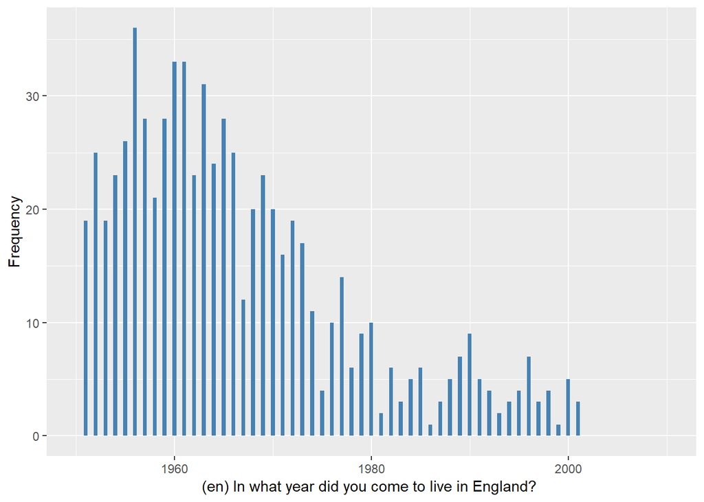

#### 2.1.1.2 Harmonisation algorithm

To compute `ymigration` from the study-specific variables they have to be recoded as follows:

- `yintw - fqceng`
- `migration = 0 into 996`
- `fqceng = -9 into 997`
- `fqceng = -8 into 998`
- `fqceng = -1 into 996`

**R script:**

```r
ELSA_ds_w1 <- tibble(id = ELSA_w1$id)
ELSA_ds_w1$ymigration <- car::recode(with(ELSA_w1, yintw - fqceng), "NA=999")
ELSA_ds_w1$ymigration[which(ELSA_w1$migration %in% c(996, 997, 998))] <- 999
ELSA_ds_w1$ymigration[which(ELSA_w1$fqceng == -1)] <- 996
ELSA_ds_w1$ymigration[which(ELSA_w1$fqceng == -9)] <- 997
ELSA_ds_w1$ymigration[which(ELSA_w1$fqceng == -8)] <- 998
ELSA_ds_w1$ymigration[which(ELSA_w1$migration == 0)] <- 996
ELSA_ds_w1$ymigration[which(ELSA_w1$migration == 999)] <- 999
```

#### 2.1.1.3 Statistics of the new harmonised variable

Years that have passed since migration

| Sample size | Missing values |
| --- | --- |
| 12099 | 11496 |

Values

|  | No-missings | 991 | 992 | 993 | 994 | 995 | 996 | 997 | 998 | 999 | NA |
| --- | --- | --- | --- | --- | --- | --- | --- | --- | --- | --- | --- |
| Frequency | 603.00 | 0 | 0 | 0 | 0 | 0 | 11409.0 | 2.00 | 5.00 | 80.00 | 0 |
| Percentage | 4.98 | 0 | 0 | 0 | 0 | 0 | 94.3 | 0.02 | 0.04 | 0.66 | 0 |

Summary

| Min. | 1st Qu. | Median | Mean | 3rd Qu. | Max. |
| --- | --- | --- | --- | --- | --- |
| 1 | 33 | 42 | 41.06 | 51 | 88 |

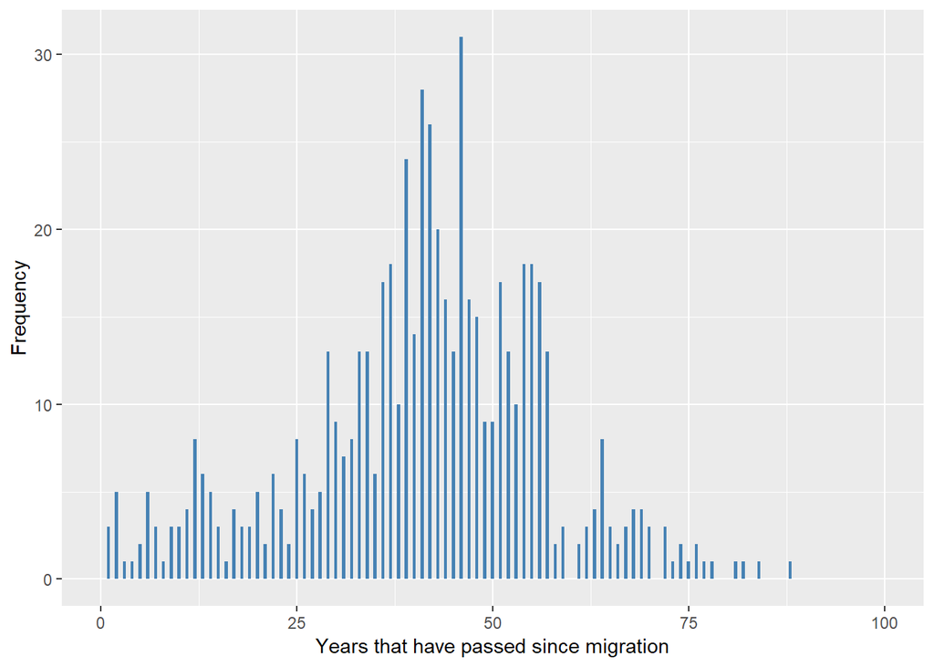

#### 2.1.1.4 Validation

### 2.1.2 Wave 2

#### 2.1.2.1 Study-specific variable description

[output not shown]

fqceng

| Sample size | Missing values |
| --- | --- |
| 9432 | 0 |

Summary

| Min. | 1st Qu. | Median | Mean | 3rd Qu. | Max. |
| --- | --- | --- | --- | --- | --- |
| -9 | -1 | -1 | 65.3 | -1 | 2003 |

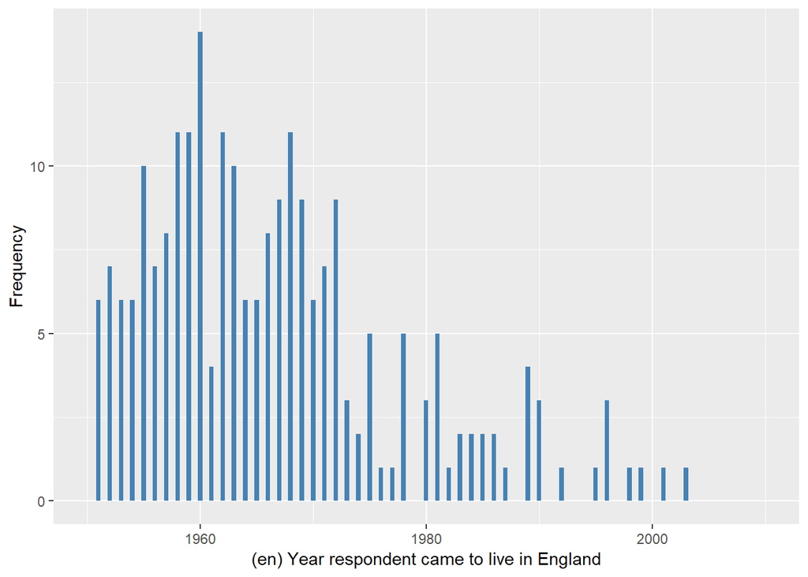

#### 2.1.2.2 Harmonisation algorithm

To compute `ymigration` from the study-specific variables they have to be recoded as follows:

- `yintw - fqceng`
- `migration = 0 into 996`
- `fqceng = -9 into 997`
- `fqceng = -8 into 998`
- `fqceng = -1 into 996`

**R script:**

```r
ELSA_ds_w2 <- tibble(id = ELSA_w2$id)
ELSA_ds_w2$ymigration <- car::recode(with(ELSA_w2, yintw - FqCeng), "NA=999")
ELSA_ds_w2$ymigration[which(ELSA_w2$migration %in% c(996, 997, 998))] <- 999
ELSA_ds_w2$ymigration[which(ELSA_w2$FqCeng == -1)] <- 996
ELSA_ds_w2$ymigration[which(ELSA_w2$FqCeng == -9)] <- 997
ELSA_ds_w2$ymigration[which(ELSA_w2$FqCeng == -8)] <- 998
ELSA_ds_w2$ymigration[which(ELSA_w2$migration == 0)] <- 996
ELSA_ds_w2$ymigration[which(ELSA_w2$migration == 999)] <- 999
```

#### 2.1.2.3 Statistics of the new harmonised variable

Years that have passed since migration

| Sample size | Missing values |
| --- | --- |
| 9432 | 9244 |

Values

|  | No-missings | 991 | 992 | 993 | 994 | 995 | 996 | 997 | 998 | 999 | NA |
| --- | --- | --- | --- | --- | --- | --- | --- | --- | --- | --- | --- |
| Frequency | 188.00 | 0 | 0 | 0 | 0 | 0 | 9239.00 | 2.00 | 1.00 | 2.00 | 0 |
| Percentage | 1.99 | 0 | 0 | 0 | 0 | 0 | 97.95 | 0.02 | 0.01 | 0.02 | 0 |

Summary

| Min. | 1st Qu. | Median | Mean | 3rd Qu. | Max. |
| --- | --- | --- | --- | --- | --- |
| 2 | 34 | 44 | 43.64 | 53 | 88 |

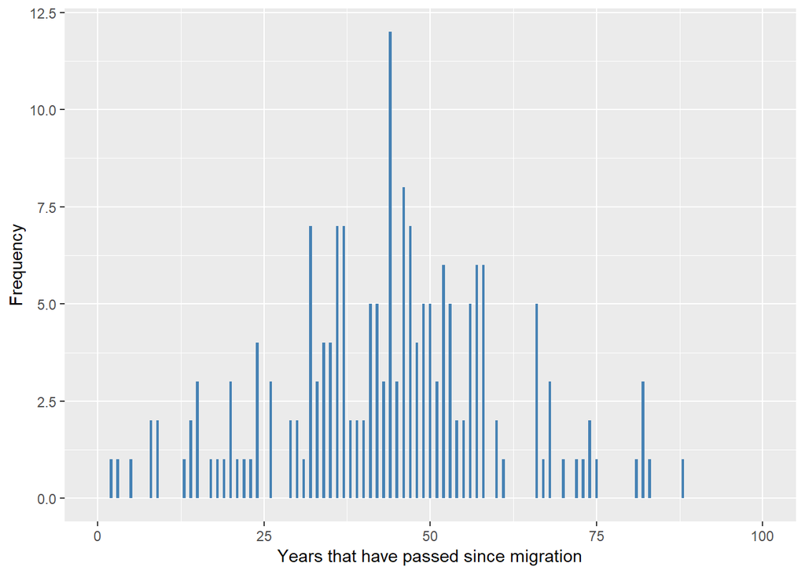

#### 2.1.2.4 Validation

### 2.1.3 Wave 3

#### 2.1.3.1 Study-specific variable description

| **Name** | `fqceng` |
| --- | --- |
| **Label** | `Year respondent came to live in England` |
| **Table name** | `wave_3_elsa_data_v4` |
| **Missings** | `-9 = Refusal` `-8 = Don't Know` `-1 = Not applicable` |
| **Description** |  |

fqceng

| Sample size | Missing values |
| --- | --- |
| 9771 | 0 |

Summary

| Min. | 1st Qu. | Median | Mean | 3rd Qu. | Max. |
| --- | --- | --- | --- | --- | --- |
| -8 | -1 | -1 | 47.89 | -1 | 2003 |

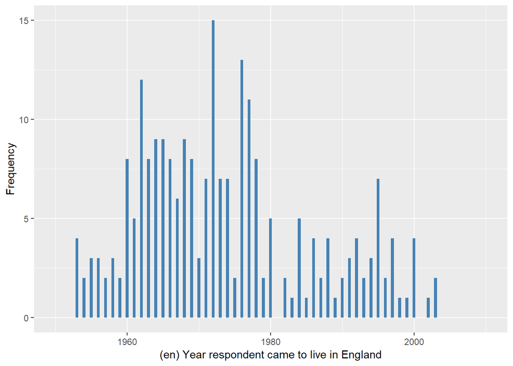

#### 2.1.3.2 Harmonisation algorithm

To compute `ymigration` from the study-specific variables they have to be recoded as follows:

- `yintw - fqceng`
- `migration = 0 into 996`
- `fqceng = -9 into 997`
- `fqceng = -8 into 998`
- `fqceng = -1 into 996`

**R script:**

```r
ELSA_ds_w3 <- tibble(id = ELSA_w3$id)
ELSA_ds_w3$ymigration <- car::recode(with(ELSA_w3, yintw - fqceng), "NA=999")
ELSA_ds_w3$ymigration[which(ELSA_w3$migration %in% c(996, 997, 998))] <- 999
ELSA_ds_w3$ymigration[which(ELSA_w3$fqceng == -1)] <- 996
ELSA_ds_w3$ymigration[which(ELSA_w3$fqceng == -9)] <- 997
ELSA_ds_w3$ymigration[which(ELSA_w3$fqceng == -8)] <- 998
ELSA_ds_w3$ymigration[which(ELSA_w3$migration == 0)] <- 996
ELSA_ds_w3$ymigration[which(ELSA_w3$migration == 999)] <- 999
```

#### 2.1.3.3 Statistics of the new harmonised variable

Years that have passed since migration

| Sample size | Missing values |
| --- | --- |
| 9771 | 9529 |

Values

|  | No-missings | 991 | 992 | 993 | 994 | 995 | 996 | 997 | 998 | 999 | NA |
| --- | --- | --- | --- | --- | --- | --- | --- | --- | --- | --- | --- |
| Frequency | 242.00 | 0 | 0 | 0 | 0 | 0 | 9528.00 | 0 | 1.00 | 0 | 0 |
| Percentage | 2.48 | 0 | 0 | 0 | 0 | 0 | 97.51 | 0 | 0.01 | 0 | 0 |

Summary

| Min. | 1st Qu. | Median | Mean | 3rd Qu. | Max. |
| --- | --- | --- | --- | --- | --- |
| 3 | 26.25 | 34 | 33.05 | 42 | 65 |

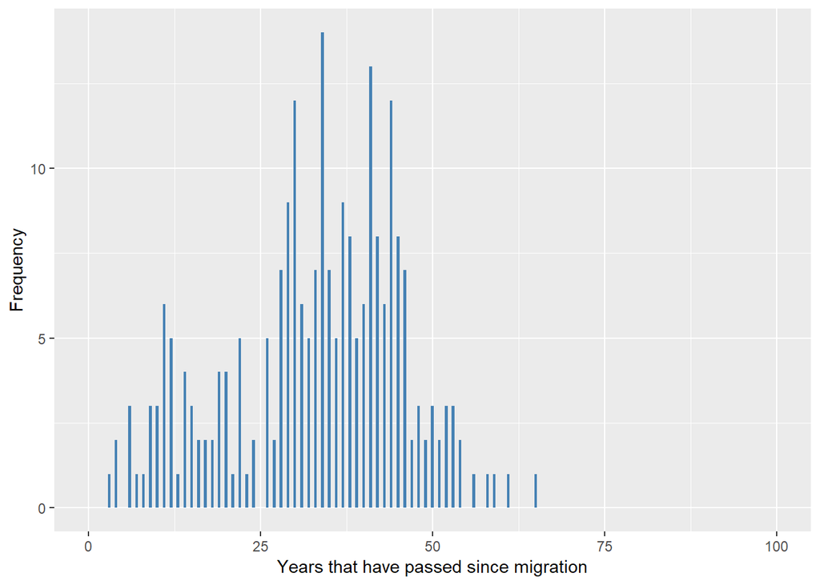

#### 2.1.3.4 Validation

### 2.1.4 Wave 4

#### 2.1.4.1 Study-specific variable description

| **Name** | `fqceng` |
| --- | --- |
| **Label** | `Year respondent came to live in England` |
| **Table name** | `wave_4_elsa_data_v3` |
| **Missings** | `-9 = Refusal` `-8 = Don't Know` `-1 = Not applicable` `-2 = Capi/Interview Error` |
| **Description** |  |

fqceng

| Sample size | Missing values |
| --- | --- |
| 11050 | 0 |

Summary

| Min. | 1st Qu. | Median | Mean | 3rd Qu. | Max. |
| --- | --- | --- | --- | --- | --- |
| -8 | -1 | -1 | 61.92 | -1 | 2008 |

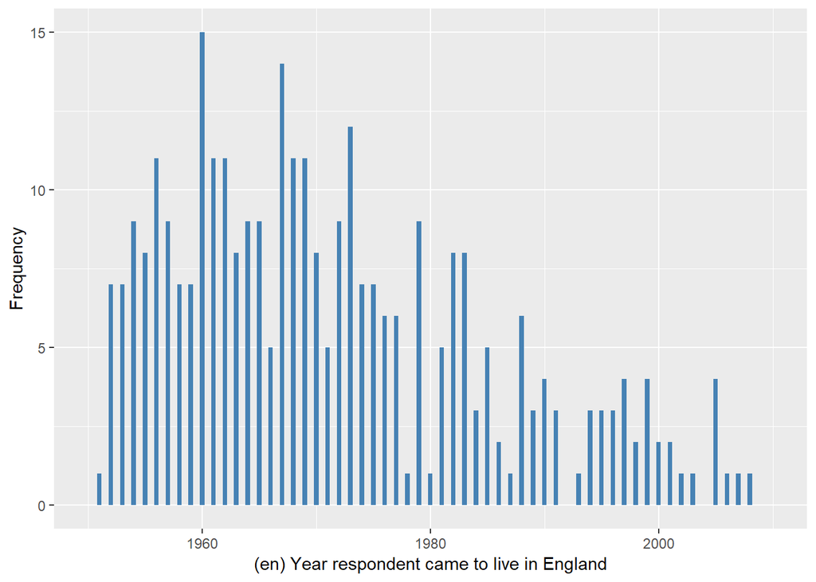

#### 2.1.4.2 Harmonisation algorithm

To compute `ymigration` from the study-specific variables they have to be recoded as follows:

- `yintw - fqceng`
- `migration = 0 into 996`
- `fqceng = -9 into 997`
- `fqceng = -8 into 998`
- `fqceng = -1 into 996`
- `fqceng = -2 into 999`

**R script:**

```r
ELSA_ds_w4 <- tibble(id = ELSA_w4$id)
ELSA_ds_w4$ymigration <- car::recode(with(ELSA_w4, yintw - fqceng), "NA=999")
ELSA_ds_w4$ymigration[which(ELSA_w4$migration %in% c(996, 997, 998))] <- 999
ELSA_ds_w4$ymigration[which(ELSA_w4$fqceng == -1)] <- 996
ELSA_ds_w4$ymigration[which(ELSA_w4$fqceng == -9)] <- 997
ELSA_ds_w4$ymigration[which(ELSA_w4$fqceng == -8)] <- 998
ELSA_ds_w4$ymigration[which(ELSA_w4$fqceng == -2)] <- 999
ELSA_ds_w4$ymigration[which(ELSA_w4$migration == 0)] <- 996
ELSA_ds_w4$ymigration[which(ELSA_w4$migration == 999)] <- 999
```

#### 2.1.4.3 Statistics of the new harmonised variable

Years that have passed since migration

| Sample size | Missing values |
| --- | --- |
| 11050 | 10697 |

Values

|  | No-missings | 991 | 992 | 993 | 994 | 995 | 996 | 997 | 998 | 999 | NA |
| --- | --- | --- | --- | --- | --- | --- | --- | --- | --- | --- | --- |
| Frequency | 353.00 | 0 | 0 | 0 | 0 | 0 | 10679.00 | 0 | 8.00 | 10.00 | 0 |
| Percentage | 3.19 | 0 | 0 | 0 | 0 | 0 | 96.64 | 0 | 0.07 | 0.09 | 0 |

Summary

| Min. | 1st Qu. | Median | Mean | 3rd Qu. | Max. |
| --- | --- | --- | --- | --- | --- |
| 0 | 30 | 41 | 39.34 | 50 | 71 |

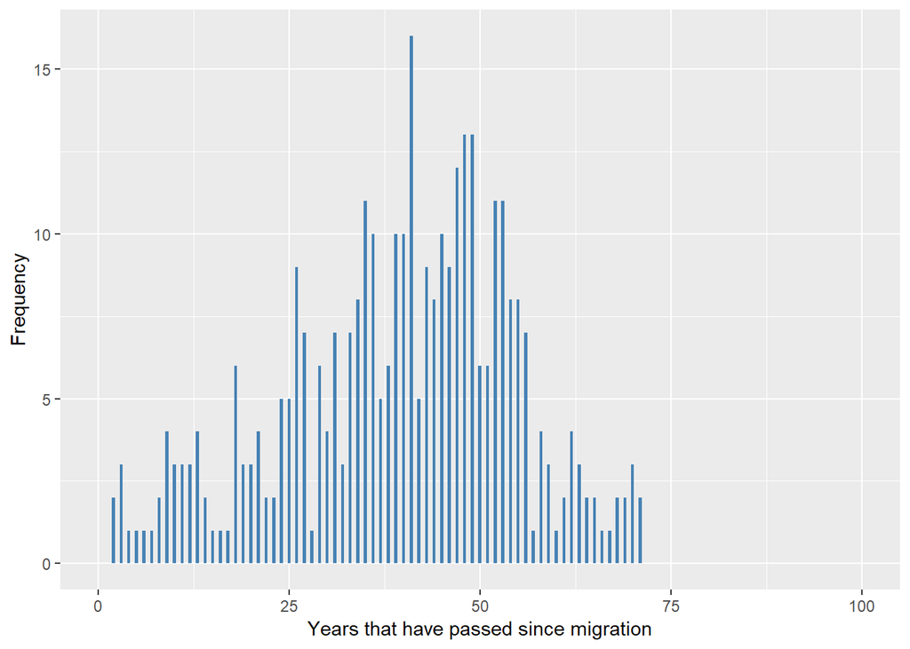

#### 2.1.4.4 Validation

### 2.1.5 Wave 5

#### 2.1.5.1 Study-specific variable description

| **Name** | `fqceng` |
| --- | --- |
| **Label** | `Year respondent came to live in England` |
| **Table name** | `wave_5_elsa_data_v4` |
| **Missings** | `-9 = Refusal` `-8 = Don't Know` `-1 = Not applicable` |
| **Description** |  |

fqceng

| Sample size | Missing values |
| --- | --- |
| 10274 | 0 |

Summary

| Min. | 1st Qu. | Median | Mean | 3rd Qu. | Max. |
| --- | --- | --- | --- | --- | --- |
| -8 | -1 | -1 | 7.25 | -1 | 2009 |

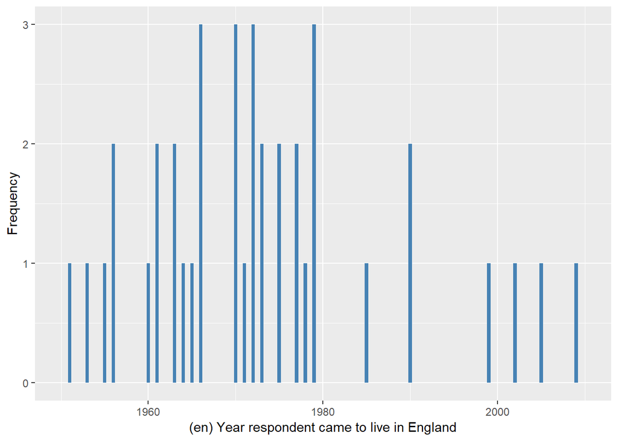

#### 2.1.5.2 Harmonisation algorithm

To compute `ymigration` from the study-specific variables they have to be recoded as follows:

- `yintw - fqceng`
- `migration = 0 into 996`
- `fqceng = -9 into 997`
- `fqceng = -8 into 998`
- `fqceng = -1 into 996`

**R script:**

```r
ELSA_ds_w5 <- tibble(id = ELSA_w5$id)
ELSA_ds_w5$ymigration <- car::recode(with(ELSA_w5, yintw - fqceng), "NA=999")
ELSA_ds_w5$ymigration[which(ELSA_w5$migration %in% c(996, 997, 998))] <- 999
ELSA_ds_w5$ymigration[which(ELSA_w5$fqceng == -1)] <- 996
ELSA_ds_w5$ymigration[which(ELSA_w5$fqceng == -9)] <- 997
ELSA_ds_w5$ymigration[which(ELSA_w5$fqceng == -8)] <- 998
ELSA_ds_w5$ymigration[which(ELSA_w5$migration == 0)] <- 996
ELSA_ds_w5$ymigration[which(ELSA_w5$migration == 999)] <- 999
```

#### 2.1.5.3 Statistics of the new harmonised variable

Years that have passed since migration

| Sample size | Missing values |
| --- | --- |
| 10274 | 10231 |

Values

|  | No-missings | 991 | 992 | 993 | 994 | 995 | 996 | 997 | 998 | 999 | NA |
| --- | --- | --- | --- | --- | --- | --- | --- | --- | --- | --- | --- |
| Frequency | 43.00 | 0 | 0 | 0 | 0 | 0 | 10230.00 | 0 | 1.00 | 0 | 0 |
| Percentage | 0.42 | 0 | 0 | 0 | 0 | 0 | 99.57 | 0 | 0.01 | 0 | 0 |

Summary

| Min. | 1st Qu. | Median | Mean | 3rd Qu. | Max. |
| --- | --- | --- | --- | --- | --- |
| 1 | 32.5 | 40 | 39.88 | 49.5 | 72 |

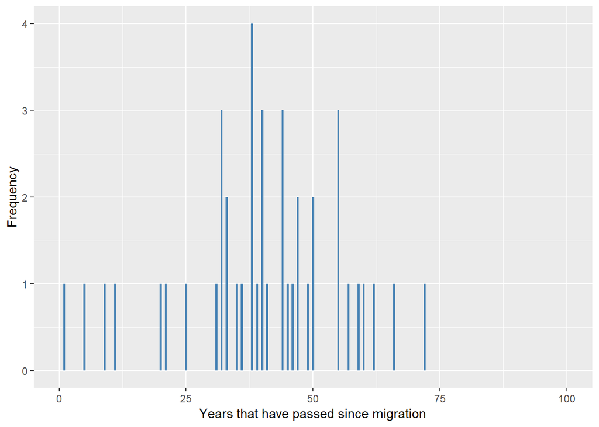

#### 2.1.5.4 Validation

### 2.1.6 Wave 6

#### 2.1.6.1 Study-specific variable description

| **Name** | `FqCeng` |
| --- | --- |
| **Label** | `year of arrival to England (QInd.QFq.FqCeng)` |
| **Table name** | `wave_6_elsa_data_v2` |
| **Missings** | `-9 = Refusal` `-8 = Don't Know` `-1 = Not applicable` |
| **Description** |  |

fqceng

| Sample size | Missing values |
| --- | --- |
| 10601 | 0 |

Summary

| Min. | 1st Qu. | Median | Mean | 3rd Qu. | Max. |
| --- | --- | --- | --- | --- | --- |
| -8 | -1 | -1 | 32.44 | -1 | 2012 |

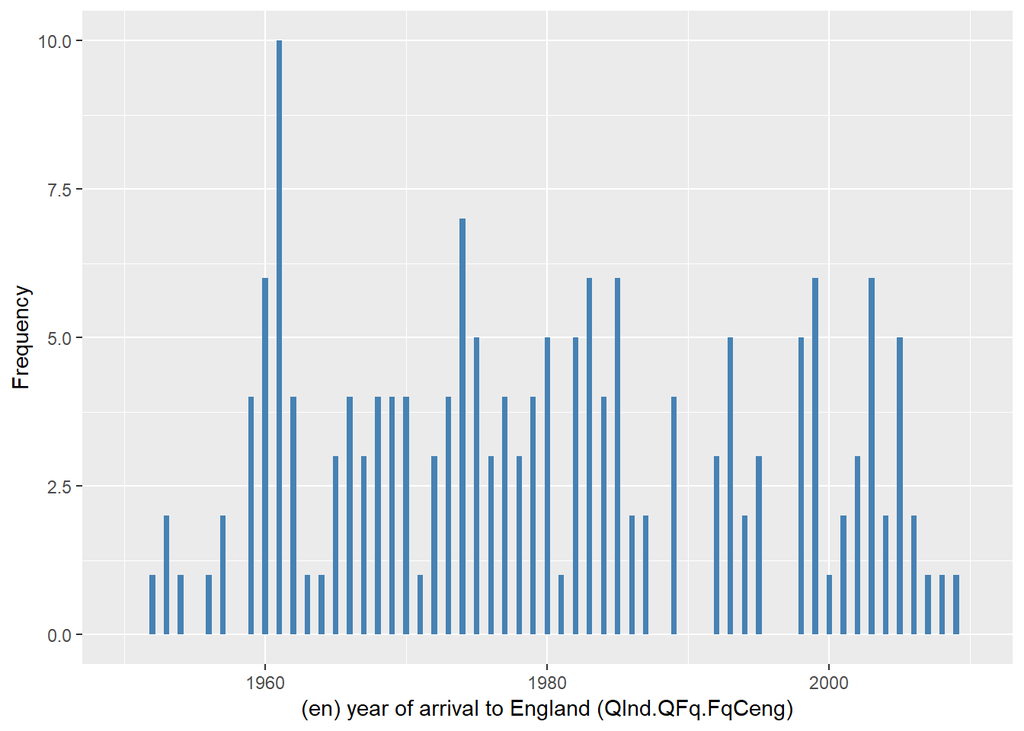

#### 2.1.6.2 Harmonisation algorithm

To compute `ymigration` from the study-specific variables they have to be recoded as follows:

- `yintw - fqceng`
- `migration = 0 into 996`
- `fqceng = -9 into 997`
- `fqceng = -8 into 998`
- `fqceng = -1 into 996`

**R script:**

```r
ELSA_ds_w6 <- tibble(id = ELSA_w6$id)
ELSA_ds_w6$ymigration <- car::recode(with(ELSA_w6, yintw - FqCeng), "NA=999")
ELSA_ds_w6$ymigration[which(ELSA_w6$migration %in% c(996, 997, 998))] <- 999
ELSA_ds_w6$ymigration[which(ELSA_w6$FqCeng == -1)] <- 996
ELSA_ds_w6$ymigration[which(ELSA_w6$FqCeng == -9)] <- 997
ELSA_ds_w6$ymigration[which(ELSA_w6$FqCeng == -8)] <- 998
ELSA_ds_w6$ymigration[which(ELSA_w6$migration == 0)] <- 996
ELSA_ds_w6$ymigration[which(ELSA_w6$migration == 999)] <- 999
```

#### 2.1.6.3 Statistics of the new harmonised variable

Years that have passed since migration

| Sample size | Missing values |
| --- | --- |
| 10601 | 10422 |

Values

|  | No-missings | 991 | 992 | 993 | 994 | 995 | 996 | 997 | 998 | 999 | NA |
| --- | --- | --- | --- | --- | --- | --- | --- | --- | --- | --- | --- |
| Frequency | 179.00 | 0 | 0 | 0 | 0 | 0 | 10420.00 | 0 | 2.00 | 0 | 0 |
| Percentage | 1.69 | 0 | 0 | 0 | 0 | 0 | 98.29 | 0 | 0.02 | 0 | 0 |

Summary

| Min. | 1st Qu. | Median | Mean | 3rd Qu. | Max. |
| --- | --- | --- | --- | --- | --- |
| 0 | 19 | 34 | 32.59 | 45 | 70 |

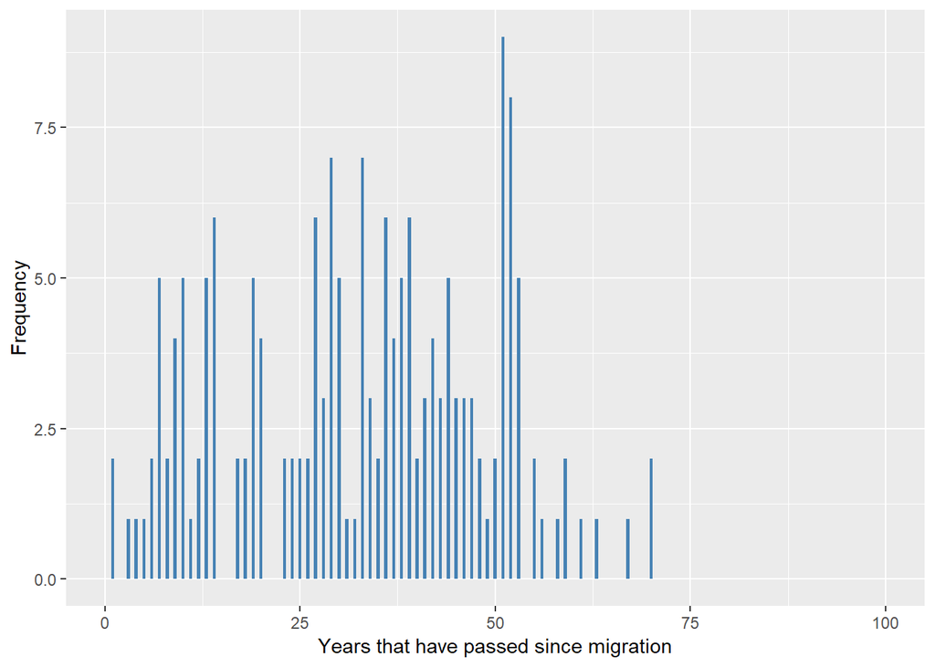

#### 2.1.6.4 Validation

### 2.1.7 Wave 7

#### 2.1.7.1 Study-specific variable description

[output not shown]

fqceng

| Sample size | Missing values |
| --- | --- |
| 9666 | 9597 |

Summary

| Min. | 1st Qu. | Median | Mean | 3rd Qu. | Max. |
| --- | --- | --- | --- | --- | --- |
| 1948 | 1970 | 1978 | 1981 | 1991 | 2013 |

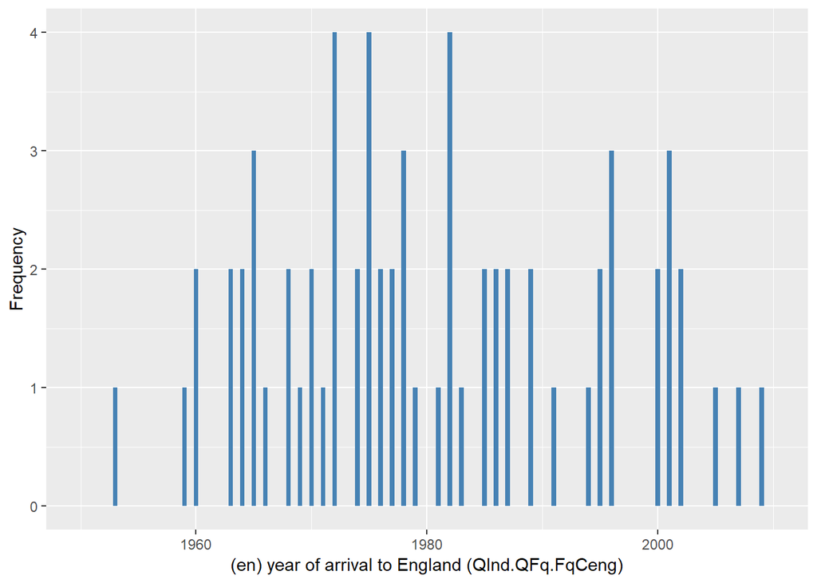

#### 2.1.7.2 Harmonisation algorithm

To compute `ymigration` from the study-specific variables they have to be recoded as follows:

- `yintw - fqceng`
- `migration = 0 into 996`
- `fqceng = -9 into 997`
- `fqceng = -8 into 998`
- `fqceng = -1 into 996`

**R script:**

```r
ELSA_ds_w7 <- tibble(id = ELSA_w7$id)
ELSA_ds_w7$ymigration <- car::recode(with(ELSA_w7, yintw - FqCeng), "NA=999")
ELSA_ds_w7$ymigration[which(ELSA_w7$migration %in% c(996, 997, 998))] <- 999
ELSA_ds_w7$ymigration[which(ELSA_w7$FqCeng == -1)] <- 996
ELSA_ds_w7$ymigration[which(ELSA_w7$FqCeng == -9)] <- 997
ELSA_ds_w7$ymigration[which(ELSA_w7$FqCeng == -8)] <- 998
ELSA_ds_w7$ymigration[which(ELSA_w7$migration == 0)] <- 996
ELSA_ds_w7$ymigration[which(ELSA_w7$migration == 999)] <- 999
```

#### 2.1.7.3 Statistics of the new harmonised variable

Years that have passed since migration

| Sample size | Missing values |
| --- | --- |
| 9666 | 9597 |

Values

|  | No-missings | 991 | 992 | 993 | 994 | 995 | 996 | 997 | 998 | 999 | NA |
| --- | --- | --- | --- | --- | --- | --- | --- | --- | --- | --- | --- |
| Frequency | 69.00 | 0 | 0 | 0 | 0 | 0 | 9596.00 | 0 | 1.00 | 0 | 0 |
| Percentage | 0.71 | 0 | 0 | 0 | 0 | 0 | 99.28 | 0 | 0.01 | 0 | 0 |

Summary

| Min. | 1st Qu. | Median | Mean | 3rd Qu. | Max. |
| --- | --- | --- | --- | --- | --- |
| 2 | 24 | 37 | 33.8 | 44 | 66 |

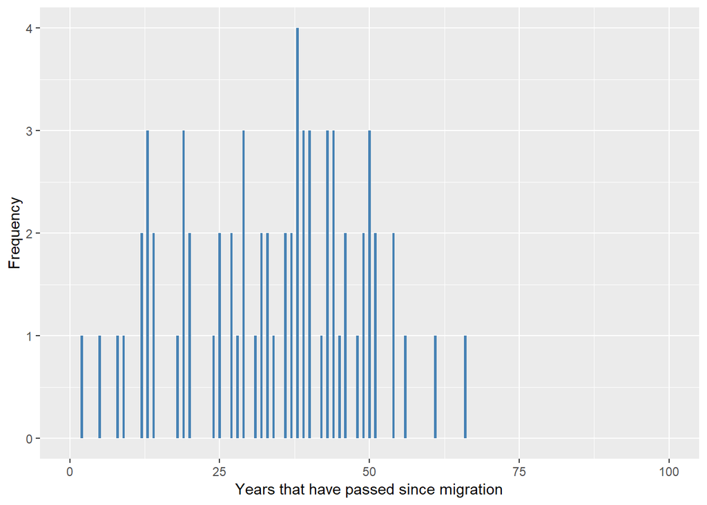

#### 2.1.7.4 Validation

## 2.2 Summary of descriptive statistics of the harmonised variable accross populations and waves

Years that have passed since migration

| ymigration | W1 | W2 | W3 | W4 | W5 | W6 | W7 |
| --- | --- | --- | --- | --- | --- | --- | --- |
| Min. | 1 | 2 | 3 | 0 | 1 | 0 | 2 |
| 1st Qu. | 33 | 34 | 26.25 | 30 | 32.5 | 19 | 24 |
| Median | 42 | 44 | 34 | 41 | 40 | 34 | 37 |
| Mean | 41.06 | 43.64 | 33.05 | 39.34 | 39.88 | 32.59 | 33.8 |
| 3rd Qu. | 51 | 53 | 42 | 50 | 49.5 | 45 | 44 |
| Max. | 88 | 88 | 65 | 71 | 72 | 70 | 66 |
| No-missings | 603 | 188 | 242 | 353 | 43 | 179 | 69 |
| 991 | 0 | 0 | 0 | 0 | 0 | 0 | 0 |
| 992 | 0 | 0 | 0 | 0 | 0 | 0 | 0 |
| 993 | 0 | 0 | 0 | 0 | 0 | 0 | 0 |
| 994 | 0 | 0 | 0 | 0 | 0 | 0 | 0 |
| 995 | 0 | 0 | 0 | 0 | 0 | 0 | 0 |
| 996 | 11409 | 9239 | 9528 | 10679 | 10230 | 10420 | 9596 |
| 997 | 2 | 2 | 0 | 0 | 0 | 0 | 0 |
| 998 | 5 | 1 | 1 | 8 | 1 | 2 | 1 |
| 999 | 80 | 2 | 0 | 10 | 0 | 0 | 0 |
| NA | 0 | 0 | 0 | 0 | 0 | 0 | 0 |
| sample size | 12099 | 9432 | 9771 | 11050 | 10274 | 10601 | 9666 |

# 3 Quality estimation

Individuals with incompatible data are specified in validations along waves.